# Amazon Copurchased

This is a Python notebook created using "jupyter".

Author: Rafael J. P. dos Santos

## Parameters

We use the parameter below to set the maximum number of edges to be read from the CSV containing edges (links).

```python
max_edges = 500000 # Set quantity to read from file
edges_csv_file = "data/20180812_links"
nodes_csv_file = "data/20180812_nodes"
```

## Load the libraries

Let's load the Python libraries that we will need throughout the script

```python
import networkx as nx
import matplotlib.pyplot as plt
import pandas as pd
from sklearn.model_selection import train_test_split
import numpy as np
from sklearn.tree import export_graphviz
import pydot
from sklearn.ensemble import RandomForestRegressor
from __future__ import division
import sklearn
#from sklearn.cross_validation import cross_val_score
from sklearn.model_selection import cross_validate
from sklearn.metrics import make_scorer
import hashlib
import sys
print('The scikit-learn version is {}.'.format(sklearn.__version__))
```

```
The scikit-learn version is 0.20.2.
```

## Read graph

### Read only first lines of datafile

Due to slowness in calculating centrality measures, we use the parameter provided in the beggining of the script to limit the number of edges we will read.

```python
lines = []
total_line_count = 0
with open(edges_csv_file, 'rb') as f:
    f.readline()   # skip first line / header
    while True:
        line = f.readline()
        if not line:
            break
        if not (max_edges > 0 and len(lines) >= max_edges):
            lines.append(line)
        total_line_count += 1
G = nx.parse_edgelist(lines, delimiter=',', nodetype=int)
```

```python
print "Using %d edges out of %d available (%.2f%% of data)" % (len(lines), total_line_count, len(lines)/total_line_count * 100)
```

```
Using 229338 edges out of 229338 available (100.00% of data)
```

### Calculate nodes centrality measures

Now that we have our NetworkX graph, let's calculate some centrality measures for every node.

```python
centrality_measures = {}
```

#### Degree

```python
centrality_measures["degree"] = nx.degree(G)
```

#### Eigenvector centrality

```python
centrality_measures["eigenvector_centrality"] = nx.eigenvector_centrality_numpy(G)
```

#### Approximate betweenness centrality (current flow)

```python
centrality_measures["betweenness_centrality"] = nx.approximate_current_flow_betweenness_centrality(G)
```

#### Closeness centrality

```python
# Very slow!
centrality_measures["closeness_centrality"] = nx.closeness_centrality(G)
```

#### Betweenness centrality

```python
# Very slow!
centrality_measures["betweenness_centrality"] = nx.betweenness_centrality(G)
```

### Load node properties

Let's load the CSV containing the nodes data (title, price) into a Pandas dataframe, and append the centrality measures calculated above.

```python
df = pd.read_csv(nodes_csv_file)
```

#### Convert ID to random int to avoid leaking knowledge

```python
sha256_ids = df['id'].map(lambda x: int(hashlib.sha256(str(x)).hexdigest()[0:8], 16))
```

```python
# Add columns to dataframe
def merge_columns(dataframe, data):
    df = dataframe.copy()
    for col in data:
        rows = []
        for item in data[col].items():
            rows.append({"id": item[0], col: item[1]})
        df = df.merge(pd.DataFrame(rows))
    return df

df = merge_columns(df, centrality_measures)
df = merge_columns(df, {'sha256_id': sha256_ids})
```

### Let's convert some fields to numeric

```python
categorical_features = [
    'category1',
    'category2',
    'category3',
    'category4',
    'category5',
    'category6',
    'category7',
    'category8',
    'category9',
    'category10',
    'language',
    'coverType',
    'publisher',
    'rankingCategory',
    'authors'
]

numeric_features = [
    #'degree',
    #'eigenvector_centrality',
    #'betweenness_centrality',
    'ranking',
    'reviewCount',
    'pages',
    'weight',
    'height',
    'width',
    'depth',
    'rating'
]

df = df.replace("<<MISSING_DATA>>", np.NaN)
df[numeric_features] = df[numeric_features].apply(pd.to_numeric)
df[['price']] = df[['price']].apply(pd.to_numeric)

for feature in numeric_features:
    df[feature].fillna(df[feature].mean(), inplace = True)
```

### Remove nodes without price

```python
df = df.drop(df[df["price"].isnull()].index)
#df = df.drop(df[df["price"] > 500].index)
```

### Inspect columns

```python
df.columns
```

```
Index([u'id', u'title', u'url', u'authors', u'coverType', u'publisher',
       u'edition', u'publicationDate', u'rankingCategory', u'category1',
       u'category2', u'category3', u'category4', u'category5', u'category6',
       u'category7', u'category8', u'category9', u'category10', u'isbn10',
       u'isbn13', u'language', u'postProcessed', u'price', u'ranking',
       u'pages', u'reviewCount', u'rating', u'width', u'height', u'depth',
       u'weight', u'eigenvector_centrality', u'degree',
       u'betweenness_centrality', u'sha256_id'],
      dtype='object')
```

### Features summary

Below we have a summary of the Pandas dataframe. We can see the number of nodes that we are actually analyzing, which depends on the max_edges parameter defined before.

```python
pd.set_option('display.max_columns', None)
#df.describe(include='all')
df.describe(include='all', percentiles=[0.25, 0.5, 0.75, 0.85, 0.9, 0.95, 0.99])
```

|  | id | title | url | authors | coverType | publisher | edition | publicationDate | rankingCategory | category1 | category2 | category3 | category4 | category5 | category6 | category7 | category8 | category9 | category10 | isbn10 | isbn13 | language | postProcessed | price | ranking | pages | reviewCount | rating | width | … |
| --- | --- | --- | --- | --- | --- | --- | --- | --- | --- | --- | --- | --- | --- | --- | --- | --- | --- | --- | --- | --- | --- | --- | --- | --- | --- | --- | --- | --- | --- | --- |
| count | 9153.000000 | 9153 | 9153 | 9152 | 9035 | 9052 | 0.0 | 783 | 8820 | 8707 | 8707 | 6525 | 3345 | 1205 | 188 | 17 | 0.0 | 0.0 | 0.0 | 9055 | 9055 | 9050 | 9153.0 | 9153.000000 | 9153.000000 | 9153.000000 | 9153.000000 | 9153.000000 | 9153.000000 | … |
| unique | NaN | 8952 | 9153 | 6177 | 11 | 728 | NaN | 574 | 1 | 1 | 28 | 228 | 440 | 309 | 71 | 8 | NaN | NaN | NaN | 9055 | 9055 | 7 | NaN | NaN | NaN | NaN | NaN | NaN | NaN | … |
| top | NaN | Macroeconomia | https://www.amazon.com.br/dp/8580332990/ | Vários Autores (Autor) | Capa comum | Companhia das Letras | NaN | 1 de janeiro de 2014 | Livros | Livros | Política, Filosofia e Ciências Sociais | Filosofia | Matemática | Brasil | Probabilidade e Estatística | Neurociência | NaN | NaN | NaN | 8525431494 | 978-8582600481 | Português | NaN | NaN | NaN | NaN | NaN | NaN | NaN | … |
| freq | NaN | 6 | 1 | 106 | 7729 | 536 | NaN | 13 | 8820 | 8707 | 1557 | 914 | 165 | 78 | 18 | 4 | NaN | NaN | NaN | 1 | 1 | 7976 | NaN | NaN | NaN | NaN | NaN | NaN | NaN | … |
| mean | 4896.658473 | NaN | NaN | NaN | NaN | NaN | NaN | NaN | NaN | NaN | NaN | NaN | NaN | NaN | NaN | NaN | NaN | NaN | NaN | NaN | NaN | NaN | 1.0 | 71.900469 | 35581.243023 | 352.333450 | 14.392313 | 4.443767 | 15.276002 | … |
| std | 2826.520995 | NaN | NaN | NaN | NaN | NaN | NaN | NaN | NaN | NaN | NaN | NaN | NaN | NaN | NaN | NaN | NaN | NaN | NaN | NaN | NaN | NaN | 0.0 | 145.716338 | 45683.667822 | 249.857638 | 32.650533 | 0.551851 | 2.574086 | … |
| min | 1.000000 | NaN | NaN | NaN | NaN | NaN | NaN | NaN | NaN | NaN | NaN | NaN | NaN | NaN | NaN | NaN | NaN | NaN | NaN | NaN | NaN | NaN | 1.0 | 2.900000 | 3.000000 | 2.000000 | 1.000000 | 1.000000 | 0.800000 | … |
| 25% | 2481.000000 | NaN | NaN | NaN | NaN | NaN | NaN | NaN | NaN | NaN | NaN | NaN | NaN | NaN | NaN | NaN | NaN | NaN | NaN | NaN | NaN | NaN | 1.0 | 26.310000 | 8345.000000 | 192.000000 | 2.000000 | 4.400000 | 13.600000 | … |
| 50% | 4900.000000 | NaN | NaN | NaN | NaN | NaN | NaN | NaN | NaN | NaN | NaN | NaN | NaN | NaN | NaN | NaN | NaN | NaN | NaN | NaN | NaN | NaN | 1.0 | 39.110000 | 22980.000000 | 304.000000 | 10.000000 | 4.445241 | 15.304075 | … |
| 75% | 7348.000000 | NaN | NaN | NaN | NaN | NaN | NaN | NaN | NaN | NaN | NaN | NaN | NaN | NaN | NaN | NaN | NaN | NaN | NaN | NaN | NaN | NaN | 1.0 | 63.110000 | 45609.000000 | 432.000000 | 14.304266 | 4.800000 | 16.000000 | … |
| 85% | 8326.200000 | NaN | NaN | NaN | NaN | NaN | NaN | NaN | NaN | NaN | NaN | NaN | NaN | NaN | NaN | NaN | NaN | NaN | NaN | NaN | NaN | NaN | 1.0 | 90.572000 | 63152.400000 | 544.000000 | 14.304266 | 5.000000 | 17.000000 | … |
| 90% | 8813.800000 | NaN | NaN | NaN | NaN | NaN | NaN | NaN | NaN | NaN | NaN | NaN | NaN | NaN | NaN | NaN | NaN | NaN | NaN | NaN | NaN | NaN | 1.0 | 120.744000 | 78753.400000 | 624.000000 | 20.000000 | 5.000000 | 18.980000 | … |
| 95% | 9294.400000 | NaN | NaN | NaN | NaN | NaN | NaN | NaN | NaN | NaN | NaN | NaN | NaN | NaN | NaN | NaN | NaN | NaN | NaN | NaN | NaN | NaN | 1.0 | 193.970000 | 107340.000000 | 784.000000 | 43.000000 | 5.000000 | 20.800000 | … |
| 99% | 9671.480000 | NaN | NaN | NaN | NaN | NaN | NaN | NaN | NaN | NaN | NaN | NaN | NaN | NaN | NaN | NaN | NaN | NaN | NaN | NaN | NaN | NaN | 1.0 | 723.754400 | 245419.320000 | 1196.880000 | 134.000000 | 5.000000 | 22.200000 | … |
| max | 9770.000000 | NaN | NaN | NaN | NaN | NaN | NaN | NaN | NaN | NaN | NaN | NaN | NaN | NaN | NaN | NaN | NaN | NaN | NaN | NaN | NaN | NaN | 1.0 | 2531.070000 | 438525.000000 | 4804.000000 | 755.000000 | 5.000000 | 35.500000 | … |

Below we can inspect the first rows of data, containing title, price, degree and other centrality measures.

```python
df.head(10)
```

|  | id | title | url | authors | coverType | publisher | edition | publicationDate | rankingCategory | category1 | category2 | category3 | category4 | category5 | category6 | category7 | category8 | category9 | category10 | isbn10 | isbn13 | language | postProcessed | price | ranking | pages | reviewCount | rating | width | … |
| --- | --- | --- | --- | --- | --- | --- | --- | --- | --- | --- | --- | --- | --- | --- | --- | --- | --- | --- | --- | --- | --- | --- | --- | --- | --- | --- | --- | --- | --- | --- |
| 0 | 1 | The Stanford Mathematics Problem Book: With Hi... | https://www.amazon.com.br/dp/0486469247/ | George Polya (Autor), | Capa comum | Dover Publications | NaN | 19 de fevereiro de 2009 | Livros | Livros | Inglês e Outras Línguas | Ciências Tecnológicas | Matemática | Estudo e Ensino | NaN | NaN | NaN | NaN | NaN | 0486469247 | 978-0486469249 | Inglês | 1 | 26.25 | 59183.0 | 68.0 | 1.000000 | 4.000000 | 14.0 | … |
| 1 | 2 | Fourier Series | https://www.amazon.com.br/dp/0486633179/ | Georgi P. Tolstov (Autor), | Capa comum | Dover Publications | NaN | 1 de junho de 1976 | Livros | Livros | Inglês e Outras Línguas | Ciências Tecnológicas | Matemática | Aplicada | Probabilidade e Estatística | NaN | NaN | NaN | NaN | 0486633179 | 978-0486633176 | Inglês | 1 | 50.37 | 56112.0 | 352.0 | 3.000000 | 4.600000 | 14.6 | … |
| 2 | 3 | Probability Theory: A Concise Course | https://www.amazon.com.br/dp/0486635449/ | Y. A. Rozanov (Autor), | Capa comum | Dover Publications | NaN | NaN | Livros | Livros | Inglês e Outras Línguas | Ciências Tecnológicas | Matemática | Aplicada | Probabilidade e Estatística | NaN | NaN | NaN | NaN | 0486635449 | 978-0486635446 | Inglês | 1 | 29.23 | 44345.0 | 160.0 | 14.304266 | 4.445241 | 14.4 | … |
| 3 | 4 | Vectors, Tensors and the Basic Equations of Fl... | https://www.amazon.com.br/dp/0486661105/ | Rutherford Aris (Autor), | Capa comum | Dover Publications | NaN | NaN | Livros | Livros | Inglês e Outras Línguas | Engenharia e Transporte | Engenharia | Mecânica | Hidráulica | NaN | NaN | NaN | NaN | 0486661105 | 978-0486661100 | Inglês | 1 | 48.79 | 82275.0 | 320.0 | 2.000000 | 4.500000 | 13.7 | … |
| 4 | 5 | Ordinary Differential Equations | https://www.amazon.com.br/dp/0486649407/ | Morris Tenenbaum (Autor), | Capa comum | Dover Publications | NaN | NaN | Livros | Livros | Inglês e Outras Línguas | Ciências Tecnológicas | Matemática | Aplicada | Equações Diferenciais | NaN | NaN | NaN | NaN | 0486649407 | 978-0486649405 | Inglês | 1 | 71.63 | 40840.0 | 848.0 | 4.000000 | 4.500000 | 13.8 | … |
| 5 | 6 | The Variational Principles of Mechanics | https://www.amazon.com.br/dp/0486650677/ | Cornelius Lanczos (Autor), | Capa comum | Dover Publications | NaN | NaN | Livros | Livros | Inglês e Outras Línguas | Ciências Tecnológicas | Física | Mecânica | NaN | NaN | NaN | NaN | NaN | 0486650677 | 978-0486650678 | Inglês | 1 | 88.15 | 36960.0 | 418.0 | 1.000000 | 5.000000 | 13.8 | … |
| 6 | 7 | A First Look at Perturbation Theory | https://www.amazon.com.br/dp/0486675513/ | James G. Simmonds (Autor) | Capa comum | Dover Publications Inc. | NaN | NaN | Livros | Livros | Inglês e Outras Línguas | Ciências Tecnológicas | Matemática | Aplicada | Equações Diferenciais | NaN | NaN | NaN | NaN | 0486675513 | 978-0486675510 | Inglês | 1 | 36.10 | 37291.0 | 160.0 | 14.304266 | 4.445241 | 13.7 | … |
| 7 | 8 | Thermodynamics and the Kinetic Theory of Gases... | https://www.amazon.com.br/dp/0486414612/ | Wolfgang Pauli (Autor), | Capa comum | Dover Publications | NaN | 18 de outubro de 2010 | Livros | Livros | Inglês e Outras Línguas | Ciências Tecnológicas | Física | Dinâmica | Termodinâmica | NaN | NaN | NaN | NaN | 0486414612 | 978-0486414614 | Inglês | 1 | 26.01 | 24406.0 | 160.0 | 2.000000 | 5.000000 | 13.8 | … |
| 8 | 9 | Mechanics | https://www.amazon.com.br/dp/0486607542/ | Jacob P. Den Hartog (Autor), | Capa comum | Dover Publications | NaN | 1 de junho de 1961 | Livros | Livros | Inglês e Outras Línguas | Ciências Tecnológicas | Física | Mecânica | NaN | NaN | NaN | NaN | NaN | 0486607542 | 978-0486607542 | Inglês | 1 | 50.96 | 90609.0 | 480.0 | 14.304266 | 4.445241 | 13.6 | … |
| 9 | 10 | Statistical Thermodynamics | https://www.amazon.com.br/dp/0486661016/ | Erwin Schrodinger (Autor), | Capa comum | Dover Publications | NaN | NaN | Livros | Livros | Inglês e Outras Línguas | Ciências Tecnológicas | Física | Dinâmica | Termodinâmica | NaN | NaN | NaN | NaN | 0486661016 | 978-0486661018 | Inglês | 1 | 32.16 | 65112.0 | 112.0 | 14.304266 | 4.445241 | 14.0 | … |

## Random forest using various features, price as target

### Preparing data

```python
df_with_dummies = pd.get_dummies(df[['sha256_id'] + numeric_features + categorical_features + ['price']],columns=categorical_features,drop_first=True)
```

```python
feature_list = list(df_with_dummies.drop(columns = ['price']))

features_values = np.array(df_with_dummies.drop(columns = ['price']))
target_value = np.array(df_with_dummies['price'])

features_and_target = np.concatenate((features_values, target_value.reshape(len(target_value), 1)), axis = 1)

#print features_and_target.shape

# Shuffle features_and_target
np.random.shuffle(features_and_target)

limit = int(round(len(target_value) * 0.8))
print "Test percentage", (len(target_value)-limit)/len(target_value)

features = features_and_target[:limit, :-1]
target = features_and_target[:limit, -1]

test_features = features_and_target[limit:, :-1]
test_target = features_and_target[limit: , -1]

print "Train features shape", features.shape
print "Train target shape", target.shape
print "Test features shape", test_features.shape
print "Test target shape", test_target.shape
```

```
Test percentage 0.200043701519
Train features shape (7322, 8006)
Train target shape (7322,)
Test features shape (1831, 8006)
Test target shape (1831,)
```

### Average price as baseline

It's important to have a baseline, so we can validate our predictions after running our model. One easy choice for baseline is the average price of a book.

```python
average_target = np.average(target)
print "Average price: R$", average_target
```

```
Average price: R$ 71.02237913138487
```

### Cross val

#### Run cross val

```python
def baseline_score_function (y_true, y_pred):
    errors_baseline = abs(average_target - y_true)
    return np.mean(errors_baseline)

def relative_error_function (y_true, y_pred):
    errors_absolute = abs(y_pred - y_true)
    errors_relative = errors_absolute / y_true
    return np.mean(errors_relative)

def baseline_relative_error_function (y_true, y_pred):
    errors_absolute = abs(average_target - y_true)
    errors_relative = errors_absolute / y_true
    return np.mean(errors_relative)

rf = RandomForestRegressor(n_estimators = 50, n_jobs = -1)

scorer = make_scorer(baseline_score_function)
scorer2 = make_scorer(relative_error_function)
scorer3 = make_scorer(baseline_relative_error_function)

scores = cross_validate(estimator=rf, X=features, y=target, cv=10,
                        scoring = {
                            'abs': 'neg_mean_absolute_error',
                            'baseline': scorer,
                            'relative': scorer2,
                            'baseline_relative': scorer3
                        },
                        return_train_score=False, return_estimator = True)

# Use best estimator to do some visual reports
rf = scores['estimator'][0]
```

#### Cross val score

```python
print "=== Relative"
print "RF relative abs mean: ", np.mean(np.abs(scores['test_relative']))
print "RF relative abs std: ", np.std(scores['test_relative'])

#print "Baseline: ", scores['test_baseline']
print "Baseline relative mean: ", np.mean(scores['test_baseline_relative'])
print "Baseline relative std: ", np.std(scores['test_baseline_relative'])

print "=== Absolute"

#print "Abs: ", scores['test_abs']
print "RF abs mean: ", np.mean(np.abs(scores['test_abs']))
print "RF abs std: ", np.std(scores['test_abs'])

#print "Baseline: ", scores['test_baseline']
print "Baseline mean: ", np.mean(scores['test_baseline'])
print "Baseline std: ", np.std(scores['test_baseline'])
```

```
=== Relative
RF relative abs mean:  0.34218196413102814
RF relative abs std:  0.016600956345595587
Baseline relative mean:  1.3086529615788804
Baseline relative std:  0.04107375898487343
=== Absolute
RF abs mean:  22.775342071358814
RF abs std:  2.052854637949908
Baseline mean:  56.41028372982995
Baseline std:  4.906440455202589
```

#### List of most important features

```python
importance = zip(feature_list, rf.feature_importances_)
importance.sort(key=lambda x:-x[1])
pd.DataFrame(importance).head(200)
```

|  | 0 | 1 |
| --- | --- | --- |
| 0 | pages | 0.205076 |
| 1 | language_Inglês | 0.183670 |
| 2 | category2_Inglês e Outras Línguas | 0.167680 |
| 3 | ranking | 0.064084 |
| 4 | height | 0.054518 |
| 5 | width | 0.052749 |
| 6 | publisher_Cengage Learning | 0.028781 |
| 7 | publisher_McGraw-Hill Science/Engineering/Math | 0.023031 |
| 8 | depth | 0.022434 |
| 9 | sha256_id | 0.022057 |
| 10 | coverType_Capa dura | 0.019940 |
| 11 | weight | 0.018314 |
| 12 | coverType_Capa comum | 0.018242 |
| 13 | authors_Lars V. Ahlfors (Autor), | 0.011535 |
| 14 | publisher_Pearson | 0.006247 |
| 15 | reviewCount | 0.004938 |
| 16 | authors_Robert G. Bartle (Autor), | 0.004642 |
| 17 | authors_J.M. Smith Termodinamica en ingenieria... | 0.003613 |
| 18 | rating | 0.003577 |
| 19 | authors_Daniel C. Alexander (Autor), | 0.002633 |
| 20 | publisher_Springer | 0.002396 |
| 21 | authors_Dr John H. Davies (Autor) | 0.002321 |
| 22 | authors_Walter Nicholson (Autor), | 0.002091 |
| 23 | authors_David L. Nelson (Autor), | 0.001998 |
| 24 | authors_S. M. Neill C. M. Ridley (Autor) | 0.001996 |
| 25 | authors_Peter J. Eccles (Autor) | 0.001954 |
| 26 | publisher_CRC Press | 0.001645 |
| 27 | publisher_Cambridge University Press | 0.001597 |
| 28 | publisher_Wiley | 0.001511 |
| 29 | publisher_McGraw-Hill Education | 0.001398 |
| ... | ... | ... |
| 170 | publisher_Sulina | 0.000088 |
| 171 | publisher_Editora Guanabara Koogan | 0.000087 |
| 172 | authors_Phillip C. Wankat (Autor) | 0.000087 |
| 173 | authors_Francis Chen (Autor) | 0.000087 |
| 174 | authors_Nelson Nery Junior (Autor), | 0.000086 |
| 175 | authors_Oscar Levin (Autor) | 0.000086 |
| 176 | category3_Matemática | 0.000086 |
| 177 | authors_Ariel Rubinstein (Posfácio), | 0.000083 |
| 178 | authors_David Quammen (Autor) | 0.000083 |
| 179 | category5_Estudo e Ensino | 0.000082 |
| 180 | publisher_Alta Books | 0.000082 |
| 181 | category3_Engenharia | 0.000079 |
| 182 | authors_Pavel Grinfeld (Autor), | 0.000076 |
| 183 | authors_Joshua Schimel (Autor) | 0.000075 |
| 184 | authors_Vijay P. Singh (Autor) | 0.000075 |
| 185 | authors_Peter Atkins (Autor), | 0.000075 |
| 186 | authors_Paul Deitel (Autor), | 0.000074 |
| 187 | authors_David E. Johnson (Autor), | 0.000074 |
| 188 | category3_Educação, Referência e Didáticos | 0.000073 |
| 189 | authors_L. D. Landau (Autor), | 0.000071 |
| 190 | category2_Engenharia e Transporte | 0.000071 |
| 191 | authors_Jean-Claude Diels (Autor), | 0.000071 |
| 192 | authors_Warren L. Stutzman (Autor), | 0.000071 |
| 193 | authors_Christian Hill (Autor) | 0.000070 |
| 194 | authors_Jonathan P. Dowling (Autor) | 0.000070 |
| 195 | authors_Ralph J. Fessenden (Autor), | 0.000070 |
| 196 | category5_Faculdade | 0.000070 |
| 197 | publisher_Editora Forense | 0.000067 |
| 198 | category4_Química | 0.000067 |
| 199 | category5_Física e Teórica | 0.000067 |

200 rows × 2 columns

## Test dataset and visual inspection

```python
test_predictions = rf.predict(test_features)
```

### Predicted price vs real price

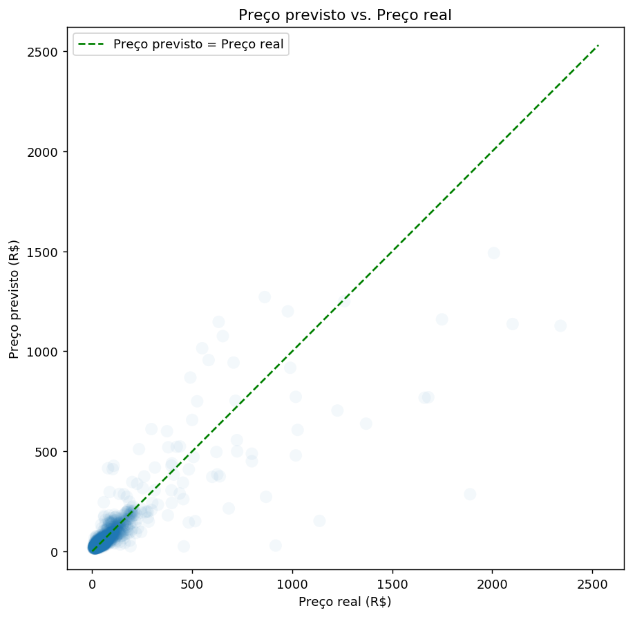

```python
plt.figure(figsize=(8,8), dpi=130)
plt.scatter(test_target, test_predictions, 100, alpha=0.05, edgecolors="none")
baseline = [0, np.max(target)]
plt.plot(baseline, baseline, "--", color="green", label = u"Preço previsto = Preço real")
ax = plt.gca()
ax.set_ylabel(u"Preço previsto (R$)")
ax.set_xlabel(u"Preço real (R$)")
ax.legend()
plt.title(u"Preço previsto vs. Preço real")
plt.axes().set_aspect('equal', 'datalim')
#plt.xlim(0, 150)
#plt.ylim(0, 150)
plt.show()
```

### Mean absolute error

Now we can compare the errors obtained by our predictions against the errors provided by the baseline (average price). Our prediction errors should be less than the baseline errors to consider the model successful.

```python
# Calculate the absolute errors
errors = abs(test_predictions - test_target)
errors_baseline = abs(average_target - test_target)
errors_relative = errors/test_target
errors_baseline_relative = errors_baseline/test_target
# Print out the mean absolute error (mae)
print "== Absolute"
print('Mean absolute prediction error: R$', round(np.mean(errors), 2))
print('Std prediction error: R$', round(np.std(errors), 2))
print('Mean absolute error using average: R$', round(np.mean(errors_baseline), 2))
print('Std prediction error using average: R$', round(np.std(errors_baseline), 2))
print "== Relative"
print('Mean relative absolute prediction error: ', round(np.mean(errors_relative), 2))
print('Std relative prediction error: ', round(np.std(errors_relative), 2))
print('Mean relative absolute error using average: ', round(np.mean(errors_baseline_relative), 2))
print('Std relative prediction error using average: ', round(np.std(errors_baseline_relative), 2))
```

```
== Absolute
('Mean absolute prediction error: R$', 24.77)
('Std prediction error: R$', 86.4)
('Mean absolute error using average: R$', 61.0)
('Std prediction error using average: R$', 151.3)
== Relative
('Mean relative absolute prediction error: ', 0.32)
('Std relative prediction error: ', 0.44)
('Mean relative absolute error using average: ', 1.32)
('Std relative prediction error using average: ', 1.51)
```

### Join data

```python
pd.set_option('display.max_columns', None)
data = {
    "all_features": test_features.tolist(),
    "sha256_id": test_features[:, 0],
    "target": test_target,
    "prediction": test_predictions,
    "error": errors,
    "error_relative": errors_relative,
    "error_baseline": errors_baseline,
    "error_baseline_relative": errors_baseline_relative
}
predicted_df = pd.DataFrame(data = data)
joined_predicted_df = predicted_df
joined_predicted_df = predicted_df.set_index("sha256_id").join(df.set_index("sha256_id"))
```

### Worst absolute predictions

Below we can inspect the rows with the biggest prediction error.

```python
joined_predicted_df.sort_values('error', ascending = False).head(20)
```

| sha256_id | all_features | error | error_baseline | error_baseline_relative | error_relative | prediction | target | id | title | url | authors | coverType | publisher | edition | publicationDate | rankingCategory | category1 | category2 | category3 | category4 | category5 | category6 | category7 | category8 | category9 | category10 | isbn10 | isbn13 | language | … |
| --- | --- | --- | --- | --- | --- | --- | --- | --- | --- | --- | --- | --- | --- | --- | --- | --- | --- | --- | --- | --- | --- | --- | --- | --- | --- | --- | --- | --- | --- | --- |
| 9.158984e+07 | [91589843.0, 311760.0, 14.3042662916, 545.0, 4... | 1603.4120 | 1817.737621 | 0.962397 | 0.848923 | 285.3480 | 1888.76 | 1712 | Vector Calculus | https://www.amazon.com.br/dp/1429215089/ | Jerrold E. Marsden (Autor), | Capa dura | W.H. Freeman & Company | NaN | NaN | Livros | Livros | Inglês e Outras Línguas | Ciências Tecnológicas | Matemática | Aplicada | Análise Vetorial | NaN | NaN | NaN | NaN | 1429215089 | 978-1429215084 | Inglês | … |
| 1.731114e+09 | [1731113829.0, 36621.5086819, 14.3042662916, 6... | 1213.8292 | 2270.177621 | 0.969664 | 0.518465 | 1127.3708 | 2341.20 | 1779 | Modern Physics for Scientists and Engineers | https://www.amazon.com.br/dp/1133103723/ | Stephen T. Thornton (Autor), | Capa dura | Cengage Learning | NaN | NaN | NaN | NaN | NaN | NaN | NaN | NaN | NaN | NaN | NaN | NaN | NaN | 1133103723 | 978-1133103721 | Inglês | … |
| 1.088718e+09 | [1088718135.0, 36621.5086819, 14.3042662916, 2... | 984.2850 | 1065.257621 | 0.937496 | 0.866235 | 151.9950 | 1136.28 | 1830 | Geometric Algebra | https://www.amazon.com.br/dp/0471608394/ | E. Artin (Autor) | Capa comum | Wiley-Blackwell | NaN | NaN | NaN | NaN | NaN | NaN | NaN | NaN | NaN | NaN | NaN | NaN | NaN | 0471608394 | 978-0471608394 | Inglês | … |
| 1.144179e+09 | [1144179495.0, 36621.5086819, 14.3042662916, 4... | 965.2696 | 2030.517621 | 0.966205 | 0.459315 | 1136.2704 | 2101.54 | 1991 | Machine Learning | https://www.amazon.com.br/dp/0070428077/ | Tom M. Mitchell (Autor), | Capa dura | McGraw-Hill Science/Engineering/Math | NaN | NaN | NaN | NaN | NaN | NaN | NaN | NaN | NaN | NaN | NaN | NaN | NaN | 0070428077 | 978-0070428072 | Inglês | … |
| 1.859584e+09 | [1859584463.0, 36621.5086819, 14.3042662916, 6... | 909.9714 | 1609.067621 | 0.957727 | 0.541621 | 770.1186 | 1680.09 | 1918 | Electric Machinery and Power System Fundamentals | https://www.amazon.com.br/dp/0072291354/ | Stephen J. Chapman (Autor) | Capa dura | McGraw-Hill Education | NaN | NaN | NaN | NaN | NaN | NaN | NaN | NaN | NaN | NaN | NaN | NaN | NaN | 0072291354 | 978-0072291353 | Inglês | … |
| 1.895458e+09 | [1895458154.0, 36621.5086819, 14.3042662916, 4... | 893.6296 | 1590.457621 | 0.957254 | 0.537852 | 767.8504 | 1661.48 | 1897 | A Transition to Advanced Mathematics | https://www.amazon.com.br/dp/1285463269/ | Douglas Smith (Autor), | Capa dura | Cengage Learning | NaN | NaN | NaN | NaN | NaN | NaN | NaN | NaN | NaN | NaN | NaN | NaN | NaN | 1285463269 | 978-1285463261 | Inglês | … |
| 2.245409e+09 | [2245408859.0, 36621.5086819, 14.3042662916, 3... | 888.3594 | 845.927621 | 0.922545 | 0.968820 | 28.5906 | 916.95 | 1965 | Introduction to Quantum Mechanics | https://www.amazon.com.br/dp/0131118927/ | David J. Griffiths (Autor) | NaN | NaN | NaN | NaN | NaN | NaN | NaN | NaN | NaN | NaN | NaN | NaN | NaN | NaN | NaN | NaN | NaN | NaN | … |
| 1.159398e+09 | [1159397835.0, 36621.5086819, 14.3042662916, 6... | 731.1710 | 1298.157621 | 0.948128 | 0.534021 | 638.0090 | 1369.18 | 1703 | Mathematical Statistics and Data Analysis [Wit... | https://www.amazon.com.br/dp/0534399428/ | John A. Rice (Autor) | Capa dura | Duxbury Resource Center | NaN | NaN | NaN | NaN | NaN | NaN | NaN | NaN | NaN | NaN | NaN | NaN | NaN | 8131519546 | 978-8131519547 | Inglês | … |
| 1.080225e+07 | [10802248.0, 44501.0, 14.3042662916, 810.0, 42... | 596.6966 | 797.967621 | 0.918270 | 0.686655 | 272.2934 | 868.99 | 6595 | Macroeconomics: Imperfections, Institutions, a... | https://www.amazon.com.br/dp/0198776225/ | Wendy Carlin (Autor), | Capa comum | Oxford University Press, USA | NaN | 2 de fevereiro de 2006 | Livros | Livros | Inglês e Outras Línguas | Administração, Negócios e Economia | Economia | Macroeconomia | NaN | NaN | NaN | NaN | NaN | 0198776225 | 978-0198776222 | Inglês | … |
| 2.082220e+09 | [2082219845.0, 36621.5086819, 14.3042662916, 7... | 588.9790 | 1677.437621 | 0.959380 | 0.336856 | 1159.4810 | 1748.46 | 1706 | Numerical Mathematics and Computing | https://www.amazon.com.br/dp/1133103715/ | E. Ward Cheney (Autor), | Capa dura | Cengage Learning | NaN | NaN | NaN | NaN | NaN | NaN | NaN | NaN | NaN | NaN | NaN | NaN | NaN | 1133103715 | 978-1133103714 | Inglês | … |
| 8.188651e+07 | [81886513.0, 409809.0, 14.3042662916, 430.0, 7... | 538.3978 | 946.697621 | 0.930214 | 0.529024 | 479.3222 | 1017.72 | 1719 | Real and Complex Analysis | https://www.amazon.com.br/dp/0070542341/ | Walter Rudin (Autor), | Capa dura | McGraw-Hill Science/Engineering/Math | NaN | NaN | Livros | Livros | Inglês e Outras Línguas | Ciências Tecnológicas | Matemática | NaN | NaN | NaN | NaN | NaN | NaN | 0070542341 | 978-0070542341 | Inglês | … |
| 1.224607e+09 | [1224607329.0, 36621.5086819, 14.3042662916, 7... | 522.2898 | 1154.907621 | 0.942067 | 0.426036 | 703.6402 | 1225.93 | 2176 | Introduction to Environmental Engineering and ... | https://www.amazon.com.br/dp/0131481932/ | Gilbert M. Masters (Autor), | Capa dura | Pearson | NaN | NaN | NaN | NaN | NaN | NaN | NaN | NaN | NaN | NaN | NaN | NaN | NaN | 0131481932 | 978-0131481930 | Inglês | … |
| 4.056917e+09 | [4056917483.0, 36621.5086819, 14.3042662916, 1... | 516.8986 | 1936.897621 | 0.964629 | 0.257430 | 1491.0214 | 2007.92 | 1970 | Physics for Scientists and Engineers: A Strate... | https://www.amazon.com.br/dp/0133953149/ | Randall D. Knight (Professor Emeritus) (Autor) | Capa dura | Pearson | NaN | NaN | NaN | NaN | NaN | NaN | NaN | NaN | NaN | NaN | NaN | NaN | NaN | 0133953149 | 978-0133953145 | Inglês | … |
| 3.803684e+09 | [3803683947.0, 36621.5086819, 14.3042662916, 9... | 515.1944 | 560.897621 | 0.887609 | 0.815284 | 1147.1144 | 631.92 | 2045 | The Nature of Computation | https://www.amazon.com.br/dp/0199233217/ | Cristopher Moore (Autor), | Capa dura | Oxford University Press, USA | NaN | 9 de outubro de 2011 | NaN | NaN | NaN | NaN | NaN | NaN | NaN | NaN | NaN | NaN | NaN | 0199233217 | 978-0199233212 | Inglês | … |
| 1.654200e+08 | [165419954.0, 79528.0, 14.3042662916, 758.0, 4... | 468.0240 | 611.447621 | 0.895933 | 0.685780 | 214.4460 | 682.47 | 2174 | Strategic Applications of Named Reactions in O... | https://www.amazon.com.br/dp/0124297854/ | Laszlo Kurti (Autor), | Capa comum | Academic Press | NaN | NaN | Livros | Livros | Inglês e Outras Línguas | Ciências Tecnológicas | Química | Orgânica | NaN | NaN | NaN | NaN | NaN | 0124297854 | 978-0124297852 | Inglês | … |
| 2.936176e+09 | [2936175769.0, 36621.5086819, 14.3042662916, 1... | 465.4208 | 478.767621 | 0.870819 | 0.846543 | 1015.2108 | 549.79 | 2049 | Optical Coherence and Quantum Optics | https://www.amazon.com.br/dp/0521417112/ | Leonard Mandel (Autor), | Capa dura | Cambridge University Press | NaN | 29 de setembro de 1995 | NaN | NaN | NaN | NaN | NaN | NaN | NaN | NaN | NaN | NaN | NaN | 0521417112 | 978-0521417112 | Inglês | … |
| 1.433239e+09 | [1433238979.0, 36621.5086819, 14.3042662916, 3... | 433.3338 | 386.827621 | 0.844878 | 0.946454 | 24.5162 | 457.85 | 330 | Quantum Computation and Quantum Information | https://www.amazon.com.br/dp/1107002176/ | Michael A. Nielsen (Autor), | NaN | NaN | NaN | NaN | NaN | NaN | NaN | NaN | NaN | NaN | NaN | NaN | NaN | NaN | NaN | NaN | NaN | NaN | … |
| 5.399116e+07 | [53991164.0, 36621.5086819, 14.3042662916, 595... | 423.0376 | 581.847621 | 0.891215 | 0.647966 | 1075.9076 | 652.87 | 2166 | Abstract Algebra: An Inquiry Based Approach | https://www.amazon.com.br/dp/1466567066/ | Jonathan K. Hodge (Autor), | Capa dura | Chapman and Hall/CRC | NaN | NaN | NaN | NaN | NaN | NaN | NaN | NaN | NaN | NaN | NaN | NaN | NaN | 1466567066 | 978-1466567061 | Inglês | … |
| 2.904504e+09 | [2904504457.0, 319780.0, 14.3042662916, 732.0,... | 419.9464 | 955.787621 | 0.930832 | 0.408982 | 606.8636 | 1026.81 | 1934 | Microwave Engineering | https://www.amazon.com.br/dp/0470631554/ | David M. Pozar (Autor) | Capa dura | John Wiley & Sons | NaN | NaN | Livros | Livros | Inglês e Outras Línguas | Engenharia e Transporte | Engenharia | Telecomunicações | Microondas | NaN | NaN | NaN | NaN | 0470631554 | 978-0470631553 | Inglês | … |
| 4.155272e+09 | [4155271538.0, 252092.0, 14.3042662916, 1488.0... | 408.5618 | 791.517621 | 0.917659 | 0.473673 | 1271.1018 | 862.54 | 1926 | Microelectronic Circuits | https://www.amazon.com.br/dp/0199339139/ | Adel Sedra (Autor), | Capa dura | Oxford University Press, USA | NaN | NaN | Livros | Livros | Inglês e Outras Línguas | Engenharia e Transporte | Engenharia | Elétrica e Eletrônica | Eletrônica | Microeletrônica | NaN | NaN | NaN | 0199339139 | 978-0199339136 | Inglês | … |

### Worst relative predictions

```python
joined_predicted_df.sort_values('error_relative', ascending = False).head(20)
```

| sha256_id | all_features | error | error_baseline | error_baseline_relative | error_relative | prediction | target | id | title | url | authors | coverType | publisher | edition | publicationDate | rankingCategory | category1 | category2 | category3 | category4 | category5 | category6 | category7 | category8 | category9 | category10 | isbn10 | isbn13 | language | … |
| --- | --- | --- | --- | --- | --- | --- | --- | --- | --- | --- | --- | --- | --- | --- | --- | --- | --- | --- | --- | --- | --- | --- | --- | --- | --- | --- | --- | --- | --- | --- |
| 3.020829e+09 | [3020829397.0, 14037.0, 48.0, 60.0, 141.0, 22.... | 17.6006 | 68.122379 | 23.490476 | 6.069172 | 20.5006 | 2.90 | 5084 | Elevador 16 | https://www.amazon.com.br/dp/8562409456/ | Rodrigo De Oliveira (Autor) | Capa comum | Faro | NaN | NaN | Livros | Livros | Literatura e Ficção | Literatura Infantojuvenil | NaN | NaN | NaN | NaN | NaN | NaN | NaN | 8562409456 | 978-8562409455 | Português | … |
| 3.013311e+09 | [3013311399.0, 153297.0, 14.3042662916, 432.0,... | 53.8050 | 60.042379 | 5.468341 | 4.900273 | 64.7850 | 10.98 | 7117 | Macrowikinomics | https://www.amazon.com.br/dp/8535243917/ | Don Tapscott (Autor), | Capa comum | Elsevier | NaN | 28 de abril de 2011 | Livros | Livros | Administração, Negócios e Economia | Indústrias e Profissões | Gestão de Sistemas de Informação | NaN | NaN | NaN | NaN | NaN | NaN | 8535243917 | 978-8535243918 | Português | … |
| 1.211805e+09 | [1211804555.0, 36621.5086819, 14.3042662916, 3... | 336.1198 | 8.077621 | 0.102119 | 4.249302 | 415.2198 | 79.10 | 2060 | Quantum Physics Workbook For Dummies | https://www.amazon.com.br/dp/0470525894/ | Steven Holzner (Autor) | Capa comum | John Wiley & Sons | NaN | NaN | NaN | NaN | NaN | NaN | NaN | NaN | NaN | NaN | NaN | NaN | NaN | 0470525894 | 978-0470525890 | Inglês | … |
| 1.150685e+09 | [1150685288.0, 28946.0, 7.0, 96.0, 422.0, 24.8... | 27.8458 | 64.122379 | 9.293098 | 4.035623 | 34.7458 | 6.90 | 7136 | Segredos de Nova York | https://www.amazon.com.br/dp/8543102405/ | Vários Autores (Autor) | Capa comum | Sextante | NaN | NaN | Livros | Livros | Arte, Cinema e Fotografia | Arte | Pinturas | NaN | NaN | NaN | NaN | NaN | NaN | 8543102405 | 978-8543102405 | Português | … |
| 7.219642e+08 | [721964190.0, 16692.0, 1.0, 472.0, 621.0, 22.8... | 33.4268 | 61.122379 | 6.173978 | 3.376444 | 43.3268 | 9.90 | 5180 | No Reino do Gelo | https://www.amazon.com.br/dp/8580579554/ | Hampton Sides (Autor), | Capa comum | Intrínseca | NaN | NaN | Livros | Livros | História | NaN | NaN | NaN | NaN | NaN | NaN | NaN | NaN | 8580579554 | 978-8580579550 | Português | … |
| 3.298496e+09 | [3298495980.0, 36621.5086819, 14.3042662916, 1... | 187.6186 | 13.482379 | 0.234313 | 3.260664 | 245.1586 | 57.54 | 2082 | GRE Prep 2018: Test Prep Book, Study Guide, & ... | https://www.amazon.com.br/dp/1628455004/ | GRE Study Guide Book 2018 Exam Team (Autor) | Capa comum | Test Prep Books | NaN | 13 de fevereiro de 2018 | NaN | NaN | NaN | NaN | NaN | NaN | NaN | NaN | NaN | NaN | NaN | 1628455004 | 978-1628455007 | Inglês | … |
| 2.398829e+09 | [2398829152.0, 365659.0, 14.3042662916, 422.0,... | 308.4424 | 31.297621 | 0.305880 | 3.014488 | 410.7624 | 102.32 | 2018 | Schaum's Outline of Probability, Random Variab... | https://www.amazon.com.br/dp/0071822984/ | Hwei P. Hsu (Autor) | Capa comum | McGraw-Hill Education | NaN | NaN | Livros | Livros | Inglês e Outras Línguas | Ciências Tecnológicas | Matemática | Análise Matemática | NaN | NaN | NaN | NaN | NaN | 0071822984 | 978-0071822985 | Inglês | … |
| 2.189980e+09 | [2189979654.0, 394545.0, 14.3042662916, 256.0,... | 320.4842 | 36.067621 | 0.336797 | 2.992662 | 427.5742 | 107.09 | 1915 | Schaum's Outline of Optics | https://www.amazon.com.br/dp/0070277303/ | Eugene Hecht (Autor), | Capa comum | McGraw-Hill | NaN | NaN | Livros | Livros | Inglês e Outras Línguas | Engenharia e Transporte | Engenharia | Elétrica e Eletrônica | Ótica | NaN | NaN | NaN | NaN | 0070277303 | 978-0070277304 | Inglês | … |
| 1.401950e+09 | [1401949622.0, 70123.0, 4.0, 416.0, 640.0, 23.... | 56.2174 | 52.122379 | 2.757798 | 2.974466 | 75.1174 | 18.90 | 2868 | Fundamentos de Administração. A Busca do Essen... | https://www.amazon.com.br/dp/8535279172/ | Sérgio Salomão (Autor), | Capa comum | Elsevier | NaN | NaN | Livros | Livros | Administração, Negócios e Economia | Gestão e Liderança | Ciência da Gestão Empresarial | NaN | NaN | NaN | NaN | NaN | NaN | 8535279172 | 978-8535279177 | Português | … |
| 1.161929e+09 | [1161929353.0, 71481.0, 2.0, 336.0, 499.0, 20.... | 28.7342 | 61.032379 | 6.109347 | 2.876296 | 38.7242 | 9.99 | 5063 | Sombra | https://www.amazon.com.br/dp/8501095540/ | Karin Alvtergen (Autor), | Capa comum | Record | NaN | NaN | Livros | Livros | Romance | NaN | NaN | NaN | NaN | NaN | NaN | NaN | NaN | 8501095540 | 978-8501095541 | Português | … |
| 2.610106e+08 | [261010615.0, 1698.0, 45.0, 84.0, 363.0, 24.8,... | 14.3532 | 66.022379 | 13.204476 | 2.870640 | 19.3532 | 5.00 | 4873 | Floresta Encantada. Livro de Colorir e Caça ao... | https://www.amazon.com.br/dp/8543101956/ | Johanna Basford (Autor), | Capa comum | Sextante | NaN | NaN | Livros | Livros | Arte, Cinema e Fotografia | Arte | Pinturas | NaN | NaN | NaN | NaN | NaN | NaN | 8543101956 | 978-8543101958 | Português | … |
| 2.591816e+09 | [2591815997.0, 1181.0, 2.0, 384.0, 522.0, 22.8... | 13.5284 | 66.122379 | 13.494363 | 2.760898 | 18.4284 | 4.90 | 5102 | Todos Envolvidos | https://www.amazon.com.br/dp/8580578108/ | Ryan Gattis (Autor), | Capa comum | Intrínseca | NaN | NaN | Livros | Livros | Romance | NaN | NaN | NaN | NaN | NaN | NaN | NaN | NaN | 8580578108 | 978-8580578102 | Português | … |
| 3.766802e+09 | [3766802256.0, 35421.0, 5.0, 588.0, 898.0, 23.... | 43.8278 | 55.022379 | 3.438899 | 2.739238 | 59.8278 | 16.00 | 5279 | Além do Feijão com Arroz. Mailson da Nóbrega, ... | https://www.amazon.com.br/dp/8520010199/ | Mailson da Nobrega (Autor) | Capa comum | Civilização Brasileira | NaN | NaN | Livros | Livros | Biografias e Histórias Reais | NaN | NaN | NaN | NaN | NaN | NaN | NaN | NaN | 8520010199 | 978-8520010198 | Português | … |
| 2.576098e+09 | [2576097882.0, 97002.0, 14.3042662916, 192.0, ... | 26.2782 | 61.222379 | 6.247182 | 2.681449 | 36.0782 | 9.80 | 3607 | O Material Humano | https://www.amazon.com.br/dp/8564065088/ | Rodrigo Rey Rosa (Autor) | Capa comum | Saraiva | NaN | NaN | Livros | Livros | Literatura e Ficção | Ficção | NaN | NaN | NaN | NaN | NaN | NaN | NaN | 8564065088 | 978-8564065086 | Português | … |
| 3.288561e+09 | [3288560668.0, 25206.0, 44.0, 448.0, 358.0, 23... | 52.8548 | 49.222379 | 2.257907 | 2.424532 | 74.6548 | 21.80 | 580 | A Teoria de Tudo | https://www.amazon.com.br/dp/8567028515/ | Jane Hawking (Autor) | Capa comum | Única | NaN | NaN | Livros | Livros | Biografias e Histórias Reais | Arte e Literatura | Autores | NaN | NaN | NaN | NaN | NaN | NaN | 8567028515 | 978-8567028514 | Português | … |
| 3.215813e+09 | [3215812862.0, 36621.5086819, 14.3042662916, 2... | 209.3584 | 15.977621 | 0.183651 | 2.406418 | 296.3584 | 87.00 | 2223 | Totally Random – Why Nobody Understands Quantu... | https://www.amazon.com.br/dp/0691176957/ | Tanya Bub (Autor), | Capa comum | Princeton University Press | NaN | 29 de junho de 2018 | NaN | NaN | NaN | NaN | NaN | NaN | NaN | NaN | NaN | NaN | NaN | 0691176957 | 978-0691176956 | Inglês | … |
| 2.505021e+09 | [2505020883.0, 62517.0, 4.0, 64.0, 558.0, 29.2... | 28.5180 | 59.032379 | 4.923468 | 2.378482 | 40.5080 | 11.99 | 2286 | Big Bang. Como o Mundo Foi Criado | https://www.amazon.com.br/dp/8581301339/ | Julie Andkjaer Olsen (Autor), | Capa dura | Geração | NaN | NaN | Livros | Livros | Infantil | Ciência e Natureza | Ficção | NaN | NaN | NaN | NaN | NaN | NaN | 8581301339 | 978-8581301334 | Português | … |
| 9.532181e+08 | [953218083.0, 42478.0, 1.0, 280.0, 599.0, 24.6... | 49.6266 | 49.122379 | 2.243031 | 2.266055 | 71.5266 | 21.90 | 7333 | A Crítica de Arte | https://www.amazon.com.br/dp/8580553814/ | Terry Barrett (Autor) | Capa comum | Mc Graw Hill | NaN | NaN | Livros | Livros | Arte, Cinema e Fotografia | NaN | NaN | NaN | NaN | NaN | NaN | NaN | NaN | 8580553814 | 978-8580553819 | Português | … |
| 3.624750e+09 | [3624749639.0, 19301.0, 14.3042662916, 448.0, ... | 35.7982 | 54.392379 | 3.270738 | 2.152628 | 52.4282 | 16.63 | 3343 | Os Anos do Condor | https://www.amazon.com.br/dp/8535906487/ | John Dinges (Autor) | Capa comum | Companhia das Letras | NaN | NaN | Livros | Livros | História | NaN | NaN | NaN | NaN | NaN | NaN | NaN | NaN | 8535906487 | 978-8535906486 | Português | … |
| 3.435546e+09 | [3435546204.0, 48320.0, 14.3042662916, 64.0, 1... | 16.0294 | 63.122379 | 7.990175 | 2.029038 | 23.9294 | 7.90 | 2266 | Sundjata, O Princípe Leão | https://www.amazon.com.br/dp/8506061989/ | Rogerio Andrade Barbosa (Autor), | Capa comum | Melhoramentos | NaN | NaN | Livros | Livros | Infantil | Literatura | Livros com Ilustração e Leituras Intermediárias | Leitura Intermediária | NaN | NaN | NaN | NaN | NaN | 8506061989 | 978-8506061985 | Português | … |

### Best absolute predictions

```python
joined_predicted_df.sort_values('error', ascending = True).head(20)
```

| sha256_id | all_features | error | error_baseline | error_baseline_relative | error_relative | prediction | target | id | title | url | authors | coverType | publisher | edition | publicationDate | rankingCategory | category1 | category2 | category3 | category4 | category5 | category6 | category7 | category8 | category9 | category10 | isbn10 | isbn13 | language | … |
| --- | --- | --- | --- | --- | --- | --- | --- | --- | --- | --- | --- | --- | --- | --- | --- | --- | --- | --- | --- | --- | --- | --- | --- | --- | --- | --- | --- | --- | --- | --- |
| 2.780514e+09 | [2780513879.0, 5803.0, 28.0, 272.0, 499.0, 22.... | 0.0000 | 57.122379 | 4.109524 | 0.000000 | 13.9000 | 13.90 | 5054 | O Regresso | https://www.amazon.com.br/dp/8580578590/ | Michael Punke (Autor), | Capa comum | Intrínseca | NaN | NaN | Livros | Livros | Romance | NaN | NaN | NaN | NaN | NaN | NaN | NaN | NaN | 8580578590 | 978-8580578591 | Português | … |
| 1.404139e+09 | [1404138776.0, 847.0, 108.0, 368.0, 358.0, 20.... | 0.0070 | 43.122379 | 1.545605 | 0.000251 | 27.9070 | 27.90 | 4652 | A Seleção | https://www.amazon.com.br/dp/8565765016/ | Kiera Cass (Autor) | Capa comum | Seguinte | NaN | NaN | Livros | Livros | Arte, Cinema e Fotografia | Teatro | NaN | NaN | NaN | NaN | NaN | NaN | NaN | 8565765016 | 978-8565765015 | Português | … |
| 2.313829e+09 | [2313829141.0, 55581.0, 14.3042662916, 168.0, ... | 0.0254 | 36.022379 | 1.029211 | 0.000726 | 34.9746 | 35.00 | 9187 | O que Aristóteles Pensou Sobre o Lugar | https://www.amazon.com.br/dp/8526810146/ | Henri Bergson (Autor), | Capa comum | Editora da Unicamp | NaN | NaN | Livros | Livros | Política, Filosofia e Ciências Sociais | Filosofia | NaN | NaN | NaN | NaN | NaN | NaN | NaN | 8526810146 | 978-8526810143 | Português | … |
| 1.048296e+08 | [104829594.0, 23895.0, 7.0, 368.0, 299.0, 20.3... | 0.0256 | 16.442379 | 0.301253 | 0.000469 | 54.6056 | 54.58 | 9323 | Leaders Eat Last: Why Some Teams Pull Together... | https://www.amazon.com.br/dp/1591848016/ | Simon Sinek (Autor) | Capa comum | Portfolio | NaN | NaN | Livros | Livros | Inglês e Outras Línguas | Administração, Negócios e Economia | Cultura do Centro de Trabalho | NaN | NaN | NaN | NaN | NaN | NaN | 1591848016 | 978-1591848011 | Inglês | … |
| 2.290427e+09 | [2290426807.0, 11687.0, 8.0, 144.0, 118.0, 17.... | 0.0260 | 57.822379 | 4.380483 | 0.001970 | 13.2260 | 13.20 | 5993 | A Metamorfose. O Veredicto - Coleção L&PM Pock... | https://www.amazon.com.br/dp/8525410462/ | Franz Kafka (Autor), | Livro de bolso | L&PM | NaN | NaN | Livros | Livros | Romance | NaN | NaN | NaN | NaN | NaN | NaN | NaN | NaN | 8525410462 | 978-8525410467 | Português | … |
| 2.902135e+09 | [2902134872.0, 11369.0, 5.0, 168.0, 240.0, 22.... | 0.0322 | 43.332379 | 1.564911 | 0.001163 | 27.6578 | 27.69 | 2625 | Conversando com Deus | https://www.amazon.com.br/dp/8576848856/ | Joseph Murphy (Autor) | Capa comum | Best Seller | NaN | NaN | Livros | Livros | Religião e Espiritualidade | Espiritualidade | NaN | NaN | NaN | NaN | NaN | NaN | NaN | 8576848856 | 978-8576848851 | Português | … |
| 1.393031e+08 | [139303063.0, 35792.0, 2.0, 528.0, 721.0, 23.4... | 0.0336 | 26.477621 | 0.271565 | 0.000345 | 97.4664 | 97.50 | 2975 | O Continente das Trevas. O Século XX na Europa | https://www.amazon.com.br/dp/9724418162/ | Mark Mazower (Autor) | Capa comum | Edições 70 | NaN | NaN | Livros | Livros | História | NaN | NaN | NaN | NaN | NaN | NaN | NaN | NaN | 9724418162 | 978-9724418162 | Português | … |
| 2.539796e+09 | [2539795765.0, 2614.0, 1.0, 126.0, 200.0, 22.6... | 0.0384 | 50.032379 | 2.383629 | 0.001829 | 21.0284 | 20.99 | 606 | A Mente Naufragada. Sobre o Espírito Reacionário | https://www.amazon.com.br/dp/8501109932/ | Mark Lilla (Autor), | Capa comum | Record | NaN | NaN | Livros | Livros | Política, Filosofia e Ciências Sociais | NaN | NaN | NaN | NaN | NaN | NaN | NaN | NaN | 8501109932 | 978-8501109934 | Português | … |
| 2.255513e+09 | [2255513493.0, 2340.0, 95.0, 416.0, 635.0, 24.... | 0.0534 | 3.877621 | 0.051771 | 0.000713 | 74.8466 | 74.90 | 3002 | Por que as Nações Fracassam. As Origens do Pod... | https://www.amazon.com.br/dp/8535238573/ | James Acemoglu Daron^Robinson (Autor) | Capa comum | Elsevier | NaN | NaN | Livros | Livros | Administração, Negócios e Economia | Economia | Internacional | NaN | NaN | NaN | NaN | NaN | NaN | 8535238573 | 978-8535238570 | Português | … |
| 3.529780e+09 | [3529780315.0, 27460.0, 1.0, 144.0, 222.0, 20.... | 0.0642 | 42.922379 | 1.527487 | 0.002285 | 28.1642 | 28.10 | 8293 | Ideia da Prosa | https://www.amazon.com.br/dp/8565381366/ | Giorgio Agamben (Autor), | Capa comum | Autêntica | NaN | NaN | Livros | Livros | Política, Filosofia e Ciências Sociais | Filosofia | NaN | NaN | NaN | NaN | NaN | NaN | NaN | 8565381366 | 978-8565381369 | Português | … |
| 3.904800e+09 | [3904800114.0, 5498.0, 12.0, 448.0, 499.0, 22.... | 0.0704 | 41.622379 | 1.415727 | 0.002395 | 29.3296 | 29.40 | 5070 | Destroçados | https://www.amazon.com.br/dp/8501111147/ | Karin Slaughter (Autor), | Capa comum | Record | NaN | NaN | Livros | Livros | Romance | NaN | NaN | NaN | NaN | NaN | NaN | NaN | NaN | 8501111147 | 978-8501111142 | Português | … |
| 3.226821e+09 | [3226821137.0, 2115.0, 45.0, 608.0, 939.0, 23.... | 0.0712 | 27.732379 | 0.640619 | 0.001645 | 43.3612 | 43.29 | 2743 | Nicolau e Alexandra | https://www.amazon.com.br/dp/8532529364/ | Robert K. Massie (Autor) | Capa comum | Rocco | NaN | NaN | Livros | Livros | Biografias e Histórias Reais | NaN | NaN | NaN | NaN | NaN | NaN | NaN | NaN | 8532529364 | 978-8532529367 | Português | … |
| 4.101435e+09 | [4101435170.0, 8489.0, 2.0, 112.0, 200.0, 20.8... | 0.0732 | 42.992379 | 1.533799 | 0.002611 | 28.1032 | 28.03 | 4131 | Liquidação | https://www.amazon.com.br/dp/8535907580/ | Imre Kertész (Autor) | Capa comum | Companhia das Letras | NaN | NaN | Livros | Livros | Romance | NaN | NaN | NaN | NaN | NaN | NaN | NaN | NaN | 8535907580 | 978-8535907582 | Português | … |
| 8.556064e+08 | [855606393.0, 31107.0, 14.3042662916, 112.0, 2... | 0.0746 | 39.102379 | 1.225012 | 0.002337 | 31.9946 | 31.92 | 5978 | O Mário Que Não É De Andrade | https://www.amazon.com.br/dp/8574061093/ | Luciana Sandroni (Autor) | Capa comum | Companhia das Letrinhas | NaN | NaN | Livros | Livros | Literatura e Ficção | Literatura Infantojuvenil | NaN | NaN | NaN | NaN | NaN | NaN | NaN | 8574061093 | 978-8574061092 | Português | … |
| 2.976687e+09 | [2976686547.0, 26100.0, 4.0, 152.0, 159.0, 22.... | 0.0824 | 41.922379 | 1.440632 | 0.002832 | 29.0176 | 29.10 | 6928 | Introdução ao JSON | https://www.amazon.com.br/dp/8575224514/ | Lindsay Bassett (Autor) | Capa comum | Novatec | NaN | NaN | Livros | Livros | Computação, Informática e Mídias Digitais | Programação | NaN | NaN | NaN | NaN | NaN | NaN | NaN | 8575224514 | 978-8575224519 | Português | … |
| 8.506317e+08 | [850631665.0, 1565.0, 81.0, 352.0, 386.0, 20.8... | 0.0890 | 44.122379 | 1.640237 | 0.003309 | 26.9890 | 26.90 | 4654 | A Escolha | https://www.amazon.com.br/dp/8565765377/ | Kiera Cass (Autor) | Capa comum | Seguinte | NaN | NaN | Livros | Livros | Jovens e Adolescentes | Literatura e Ficção | Romance | Contemporâneo | NaN | NaN | NaN | NaN | NaN | 8565765377 | 978-8565765374 | Português | … |
| 3.898262e+09 | [3898262234.0, 6402.0, 14.3042662916, 48.0, 81... | 0.0942 | 52.102379 | 2.753826 | 0.004979 | 18.8258 | 18.92 | 7576 | Elogio da Filosofia Antiga | https://www.amazon.com.br/dp/8515039508/ | Pierre Hadot (Autor) | Capa comum | Loyola | NaN | NaN | Livros | Livros | Religião e Espiritualidade | NaN | NaN | NaN | NaN | NaN | NaN | NaN | NaN | 8515039508 | 978-8515039500 | Português | … |
| 2.402852e+08 | [240285171.0, 10651.0, 14.3042662916, 112.0, 2... | 0.0956 | 43.122379 | 1.545605 | 0.003427 | 27.8044 | 27.90 | 7979 | Sociologia das Religiões | https://www.amazon.com.br/dp/8527411458/ | Max Weber (Autor) | Capa comum | Ícone | NaN | NaN | Livros | Livros | Política, Filosofia e Ciências Sociais | Filosofia | Político | NaN | NaN | NaN | NaN | NaN | NaN | 8527411458 | 978-8527411455 | Português | … |
| 4.065887e+09 | [4065887387.0, 10534.0, 3.0, 296.0, 381.0, 21.... | 0.1004 | 35.122379 | 0.978339 | 0.002797 | 35.7996 | 35.90 | 5546 | Escola Brasileira de Futebol | https://www.amazon.com.br/dp/8547000577/ | Paulo Vinícius Coelho (Autor) | Capa comum | Objetiva | NaN | NaN | Livros | Livros | Esportes e Lazer | Diversos | História do Esporte | NaN | NaN | NaN | NaN | NaN | NaN | 8547000577 | 978-8547000578 | Português | … |
| 6.223508e+08 | [622350836.0, 15120.0, 6.0, 208.0, 376.0, 22.9... | 0.1134 | 41.022379 | 1.367413 | 0.003780 | 29.8866 | 30.00 | 3273 | Economia em Uma Única Lição | https://www.amazon.com.br/dp/8562816175/ | Henry Hazlitt (Autor) | Capa comum | Mises | NaN | NaN | Livros | Livros | Política, Filosofia e Ciências Sociais | Governo e Política | Relações Públicas e Política | Política Econômica | NaN | NaN | NaN | NaN | NaN | 8562816175 | 978-8562816178 | Português | … |

```python
joined_predicted_df.sort_values('error', ascending = True).head(20)
```

| sha256_id | all_features | error | error_baseline | error_baseline_relative | error_relative | prediction | target | id | title | url | authors | coverType | publisher | edition | publicationDate | rankingCategory | category1 | category2 | category3 | category4 | category5 | category6 | category7 | category8 | category9 | category10 | isbn10 | isbn13 | language | … |
| --- | --- | --- | --- | --- | --- | --- | --- | --- | --- | --- | --- | --- | --- | --- | --- | --- | --- | --- | --- | --- | --- | --- | --- | --- | --- | --- | --- | --- | --- | --- |
| 2.780514e+09 | [2780513879.0, 5803.0, 28.0, 272.0, 499.0, 22.... | 0.0000 | 57.122379 | 4.109524 | 0.000000 | 13.9000 | 13.90 | 5054 | O Regresso | https://www.amazon.com.br/dp/8580578590/ | Michael Punke (Autor), | Capa comum | Intrínseca | NaN | NaN | Livros | Livros | Romance | NaN | NaN | NaN | NaN | NaN | NaN | NaN | NaN | 8580578590 | 978-8580578591 | Português | … |
| 1.404139e+09 | [1404138776.0, 847.0, 108.0, 368.0, 358.0, 20.... | 0.0070 | 43.122379 | 1.545605 | 0.000251 | 27.9070 | 27.90 | 4652 | A Seleção | https://www.amazon.com.br/dp/8565765016/ | Kiera Cass (Autor) | Capa comum | Seguinte | NaN | NaN | Livros | Livros | Arte, Cinema e Fotografia | Teatro | NaN | NaN | NaN | NaN | NaN | NaN | NaN | 8565765016 | 978-8565765015 | Português | … |
| 2.313829e+09 | [2313829141.0, 55581.0, 14.3042662916, 168.0, ... | 0.0254 | 36.022379 | 1.029211 | 0.000726 | 34.9746 | 35.00 | 9187 | O que Aristóteles Pensou Sobre o Lugar | https://www.amazon.com.br/dp/8526810146/ | Henri Bergson (Autor), | Capa comum | Editora da Unicamp | NaN | NaN | Livros | Livros | Política, Filosofia e Ciências Sociais | Filosofia | NaN | NaN | NaN | NaN | NaN | NaN | NaN | 8526810146 | 978-8526810143 | Português | … |
| 1.048296e+08 | [104829594.0, 23895.0, 7.0, 368.0, 299.0, 20.3... | 0.0256 | 16.442379 | 0.301253 | 0.000469 | 54.6056 | 54.58 | 9323 | Leaders Eat Last: Why Some Teams Pull Together... | https://www.amazon.com.br/dp/1591848016/ | Simon Sinek (Autor) | Capa comum | Portfolio | NaN | NaN | Livros | Livros | Inglês e Outras Línguas | Administração, Negócios e Economia | Cultura do Centro de Trabalho | NaN | NaN | NaN | NaN | NaN | NaN | 1591848016 | 978-1591848011 | Inglês | … |
| 2.290427e+09 | [2290426807.0, 11687.0, 8.0, 144.0, 118.0, 17.... | 0.0260 | 57.822379 | 4.380483 | 0.001970 | 13.2260 | 13.20 | 5993 | A Metamorfose. O Veredicto - Coleção L&PM Pock... | https://www.amazon.com.br/dp/8525410462/ | Franz Kafka (Autor), | Livro de bolso | L&PM | NaN | NaN | Livros | Livros | Romance | NaN | NaN | NaN | NaN | NaN | NaN | NaN | NaN | 8525410462 | 978-8525410467 | Português | … |
| 2.902135e+09 | [2902134872.0, 11369.0, 5.0, 168.0, 240.0, 22.... | 0.0322 | 43.332379 | 1.564911 | 0.001163 | 27.6578 | 27.69 | 2625 | Conversando com Deus | https://www.amazon.com.br/dp/8576848856/ | Joseph Murphy (Autor) | Capa comum | Best Seller | NaN | NaN | Livros | Livros | Religião e Espiritualidade | Espiritualidade | NaN | NaN | NaN | NaN | NaN | NaN | NaN | 8576848856 | 978-8576848851 | Português | … |
| 1.393031e+08 | [139303063.0, 35792.0, 2.0, 528.0, 721.0, 23.4... | 0.0336 | 26.477621 | 0.271565 | 0.000345 | 97.4664 | 97.50 | 2975 | O Continente das Trevas. O Século XX na Europa | https://www.amazon.com.br/dp/9724418162/ | Mark Mazower (Autor) | Capa comum | Edições 70 | NaN | NaN | Livros | Livros | História | NaN | NaN | NaN | NaN | NaN | NaN | NaN | NaN | 9724418162 | 978-9724418162 | Português | … |
| 2.539796e+09 | [2539795765.0, 2614.0, 1.0, 126.0, 200.0, 22.6... | 0.0384 | 50.032379 | 2.383629 | 0.001829 | 21.0284 | 20.99 | 606 | A Mente Naufragada. Sobre o Espírito Reacionário | https://www.amazon.com.br/dp/8501109932/ | Mark Lilla (Autor), | Capa comum | Record | NaN | NaN | Livros | Livros | Política, Filosofia e Ciências Sociais | NaN | NaN | NaN | NaN | NaN | NaN | NaN | NaN | 8501109932 | 978-8501109934 | Português | … |
| 2.255513e+09 | [2255513493.0, 2340.0, 95.0, 416.0, 635.0, 24.... | 0.0534 | 3.877621 | 0.051771 | 0.000713 | 74.8466 | 74.90 | 3002 | Por que as Nações Fracassam. As Origens do Pod... | https://www.amazon.com.br/dp/8535238573/ | James Acemoglu Daron^Robinson (Autor) | Capa comum | Elsevier | NaN | NaN | Livros | Livros | Administração, Negócios e Economia | Economia | Internacional | NaN | NaN | NaN | NaN | NaN | NaN | 8535238573 | 978-8535238570 | Português | … |
| 3.529780e+09 | [3529780315.0, 27460.0, 1.0, 144.0, 222.0, 20.... | 0.0642 | 42.922379 | 1.527487 | 0.002285 | 28.1642 | 28.10 | 8293 | Ideia da Prosa | https://www.amazon.com.br/dp/8565381366/ | Giorgio Agamben (Autor), | Capa comum | Autêntica | NaN | NaN | Livros | Livros | Política, Filosofia e Ciências Sociais | Filosofia | NaN | NaN | NaN | NaN | NaN | NaN | NaN | 8565381366 | 978-8565381369 | Português | … |
| 3.904800e+09 | [3904800114.0, 5498.0, 12.0, 448.0, 499.0, 22.... | 0.0704 | 41.622379 | 1.415727 | 0.002395 | 29.3296 | 29.40 | 5070 | Destroçados | https://www.amazon.com.br/dp/8501111147/ | Karin Slaughter (Autor), | Capa comum | Record | NaN | NaN | Livros | Livros | Romance | NaN | NaN | NaN | NaN | NaN | NaN | NaN | NaN | 8501111147 | 978-8501111142 | Português | … |
| 3.226821e+09 | [3226821137.0, 2115.0, 45.0, 608.0, 939.0, 23.... | 0.0712 | 27.732379 | 0.640619 | 0.001645 | 43.3612 | 43.29 | 2743 | Nicolau e Alexandra | https://www.amazon.com.br/dp/8532529364/ | Robert K. Massie (Autor) | Capa comum | Rocco | NaN | NaN | Livros | Livros | Biografias e Histórias Reais | NaN | NaN | NaN | NaN | NaN | NaN | NaN | NaN | 8532529364 | 978-8532529367 | Português | … |
| 4.101435e+09 | [4101435170.0, 8489.0, 2.0, 112.0, 200.0, 20.8... | 0.0732 | 42.992379 | 1.533799 | 0.002611 | 28.1032 | 28.03 | 4131 | Liquidação | https://www.amazon.com.br/dp/8535907580/ | Imre Kertész (Autor) | Capa comum | Companhia das Letras | NaN | NaN | Livros | Livros | Romance | NaN | NaN | NaN | NaN | NaN | NaN | NaN | NaN | 8535907580 | 978-8535907582 | Português | … |
| 8.556064e+08 | [855606393.0, 31107.0, 14.3042662916, 112.0, 2... | 0.0746 | 39.102379 | 1.225012 | 0.002337 | 31.9946 | 31.92 | 5978 | O Mário Que Não É De Andrade | https://www.amazon.com.br/dp/8574061093/ | Luciana Sandroni (Autor) | Capa comum | Companhia das Letrinhas | NaN | NaN | Livros | Livros | Literatura e Ficção | Literatura Infantojuvenil | NaN | NaN | NaN | NaN | NaN | NaN | NaN | 8574061093 | 978-8574061092 | Português | … |
| 2.976687e+09 | [2976686547.0, 26100.0, 4.0, 152.0, 159.0, 22.... | 0.0824 | 41.922379 | 1.440632 | 0.002832 | 29.0176 | 29.10 | 6928 | Introdução ao JSON | https://www.amazon.com.br/dp/8575224514/ | Lindsay Bassett (Autor) | Capa comum | Novatec | NaN | NaN | Livros | Livros | Computação, Informática e Mídias Digitais | Programação | NaN | NaN | NaN | NaN | NaN | NaN | NaN | 8575224514 | 978-8575224519 | Português | … |
| 8.506317e+08 | [850631665.0, 1565.0, 81.0, 352.0, 386.0, 20.8... | 0.0890 | 44.122379 | 1.640237 | 0.003309 | 26.9890 | 26.90 | 4654 | A Escolha | https://www.amazon.com.br/dp/8565765377/ | Kiera Cass (Autor) | Capa comum | Seguinte | NaN | NaN | Livros | Livros | Jovens e Adolescentes | Literatura e Ficção | Romance | Contemporâneo | NaN | NaN | NaN | NaN | NaN | 8565765377 | 978-8565765374 | Português | … |
| 3.898262e+09 | [3898262234.0, 6402.0, 14.3042662916, 48.0, 81... | 0.0942 | 52.102379 | 2.753826 | 0.004979 | 18.8258 | 18.92 | 7576 | Elogio da Filosofia Antiga | https://www.amazon.com.br/dp/8515039508/ | Pierre Hadot (Autor) | Capa comum | Loyola | NaN | NaN | Livros | Livros | Religião e Espiritualidade | NaN | NaN | NaN | NaN | NaN | NaN | NaN | NaN | 8515039508 | 978-8515039500 | Português | … |
| 2.402852e+08 | [240285171.0, 10651.0, 14.3042662916, 112.0, 2... | 0.0956 | 43.122379 | 1.545605 | 0.003427 | 27.8044 | 27.90 | 7979 | Sociologia das Religiões | https://www.amazon.com.br/dp/8527411458/ | Max Weber (Autor) | Capa comum | Ícone | NaN | NaN | Livros | Livros | Política, Filosofia e Ciências Sociais | Filosofia | Político | NaN | NaN | NaN | NaN | NaN | NaN | 8527411458 | 978-8527411455 | Português | … |
| 4.065887e+09 | [4065887387.0, 10534.0, 3.0, 296.0, 381.0, 21.... | 0.1004 | 35.122379 | 0.978339 | 0.002797 | 35.7996 | 35.90 | 5546 | Escola Brasileira de Futebol | https://www.amazon.com.br/dp/8547000577/ | Paulo Vinícius Coelho (Autor) | Capa comum | Objetiva | NaN | NaN | Livros | Livros | Esportes e Lazer | Diversos | História do Esporte | NaN | NaN | NaN | NaN | NaN | NaN | 8547000577 | 978-8547000578 | Português | … |
| 6.223508e+08 | [622350836.0, 15120.0, 6.0, 208.0, 376.0, 22.9... | 0.1134 | 41.022379 | 1.367413 | 0.003780 | 29.8866 | 30.00 | 3273 | Economia em Uma Única Lição | https://www.amazon.com.br/dp/8562816175/ | Henry Hazlitt (Autor) | Capa comum | Mises | NaN | NaN | Livros | Livros | Política, Filosofia e Ciências Sociais | Governo e Política | Relações Públicas e Política | Política Econômica | NaN | NaN | NaN | NaN | NaN | 8562816175 | 978-8562816178 | Português | … |

### Relative errors distribution

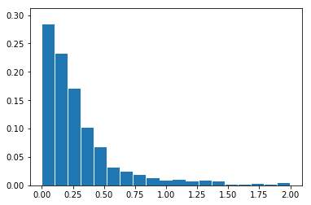

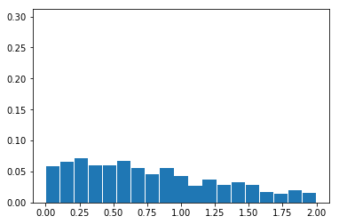

```python
count = len(predicted_df.error_relative)
hist_predicted = np.histogram(predicted_df.error_relative, np.linspace(0, 2, 20))
normalized_hist_predicted = hist_predicted[0]/count
hist_baseline = np.histogram(predicted_df.error_baseline_relative, np.linspace(0, 2, 20))
normalized_hist_baseline = hist_baseline[0]/count
centers = np.convolve(hist_predicted[1], [0.5, 0.5])
centers = centers[1:-1]
plt.bar(centers, normalized_hist_predicted, width=(centers[1]-centers[0])*0.95)
ylim = max(hist_predicted[0]/count) * 1.1
plt.ylim(0, ylim)
plt.show()
plt.bar(centers, normalized_hist_baseline, width=(centers[1]-centers[0])*0.95)
plt.ylim(0, ylim)
plt.show()
```

#### Accumulated

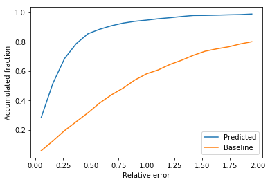

```python
def accumulated_distribution(histogram):
    accumulated = []
    total = 0
    for value in histogram:
        total += value
        accumulated.append(total)
    return accumulated


plt.plot(centers, accumulated_distribution(normalized_hist_predicted), label='Predicted')
plt.plot(centers, accumulated_distribution(normalized_hist_baseline), label='Baseline')
plt.xlabel('Relative error')
plt.ylabel('Accumulated fraction')
plt.legend(loc='lower right')
plt.show()
```

### Joined data summary

```python
predicted_df.describe(percentiles=[0.25, 0.5, 0.75, 0.85, 0.9, 0.95, 0.99])
```

|  | error | error_baseline | error_baseline_relative | error_relative | prediction | sha256_id | target |
| --- | --- | --- | --- | --- | --- | --- | --- |
| count | 1831.000000 | 1831.000000 | 1831.000000 | 1831.000000 | 1831.000000 | 1.831000e+03 | 1831.000000 |
| mean | 24.772057 | 60.995130 | 1.319510 | 0.320446 | 69.093042 | 2.111631e+09 | 75.411868 |
| std | 86.426207 | 151.344756 | 1.506292 | 0.439411 | 121.956405 | 1.254074e+09 | 163.120802 |
| min | 0.000000 | 0.122379 | 0.001726 | 0.000000 | 12.765400 | 2.360530e+05 | 2.900000 |
| 25% | 3.606700 | 24.517379 | 0.409616 | 0.093722 | 28.508900 | 1.001152e+09 | 26.590000 |
| 50% | 7.888800 | 38.447621 | 0.872459 | 0.197447 | 37.729200 | 2.131371e+09 | 38.900000 |
| 75% | 15.919600 | 50.122379 | 1.671019 | 0.376129 | 59.292900 | 3.184995e+09 | 62.850000 |
| 85% | 25.211100 | 56.822379 | 2.390915 | 0.516342 | 85.844500 | 3.636019e+09 | 92.900000 |
| 90% | 34.900400 | 62.362379 | 2.923888 | 0.676722 | 120.927600 | 3.880592e+09 | 124.340000 |
| 95% | 72.306100 | 123.032621 | 4.076653 | 1.076291 | 184.597500 | 4.067133e+09 | 194.055000 |
| 99% | 416.531020 | 772.119621 | 6.900153 | 2.115551 | 736.105220 | 4.252809e+09 | 843.142000 |
| max | 1603.412000 | 2270.177621 | 23.490476 | 6.069172 | 1491.021400 | 4.294367e+09 | 2341.200000 |

### Visualize decision tree

```python
# Pull out one tree from the forest
tree = rf.estimators_[0]
# Export the image to a dot file
export_graphviz(tree, out_file = 'tree.dot',
                feature_names = feature_list, rounded = True)
# Use dot file to create a graph
(graph, ) = pydot.graph_from_dot_file('tree.dot')
# Write graph to a png file
graph.write_png('tree.png')
```

[figure not shown]